# FluSight Manuscript 2021-2023

Author

CDC FluSight Team

Published

March 26, 2024

## Results

The second peak exhibited higher weekly numbers of hospital admissions, with reported national weekly influenza hospital admissions exceeding 1000 for 19 out of 21 of the forecast weeks, though reporting of influenza hospitalizations was not mandatory in the HHS system until February 2, 2022. Weekly numbers of admissions for 2022-23, exceeded 1000 for 27 out of 34 of the forecast weeks.

##### Forecasts & Observed (Figure 1)

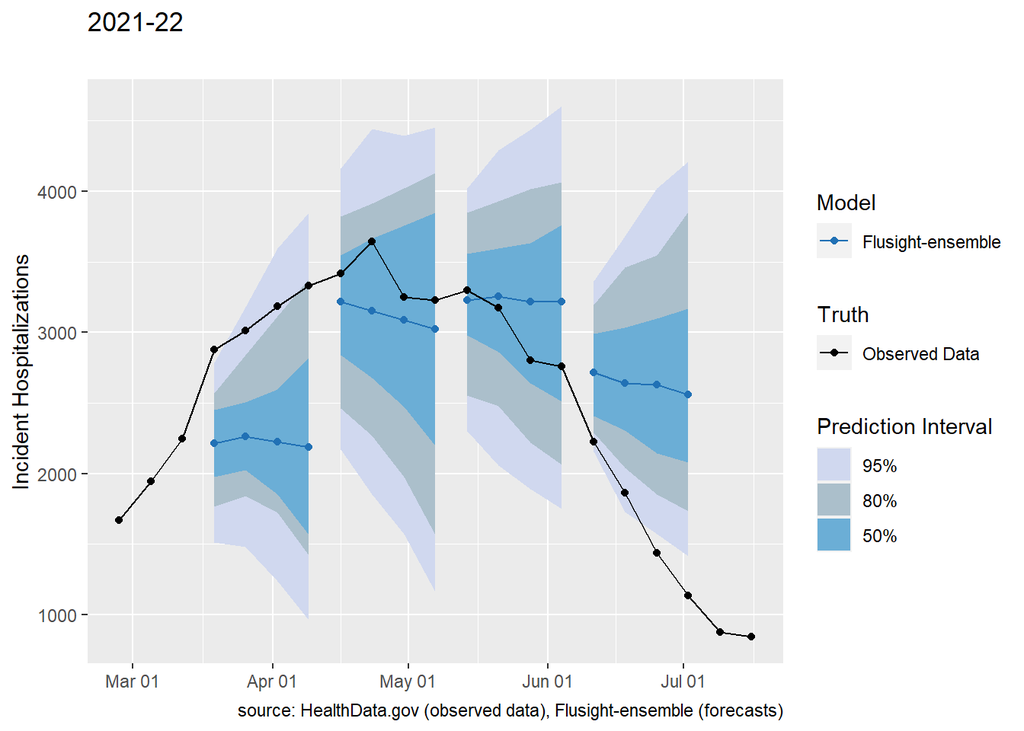

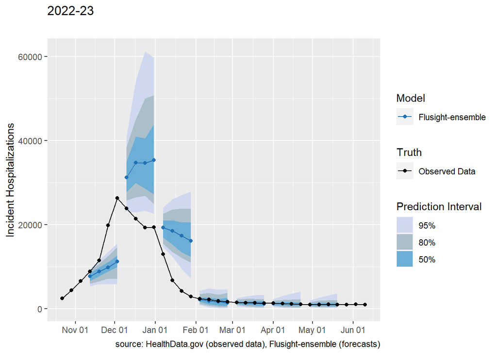